# Grammar of Graphic

Jean Castaing

6 octobre 2018

# Understanding the grammar of graphics

# 1) Data

Datasets mtcars : Motor Trend Car Road Tests

### Description

The data was extracted from the 1974 Motor Trend US magazine, and comprises fuel consumption and 10 aspects of automobile design and performance for 32 automobiles (1973-74 models).

### Format

A data frame with 32 observations on 11 (numeric) variables.

[, 1] mpg Miles/(US) gallon [, 2] cyl Number of cylinders [, 3] disp Displacement (cu.in.) [, 4] hp Gross horsepower [, 5] drat Rear axle ratio [, 6] wt Weight (1000 lbs) [, 7] qsec 1/4 mile time [, 8] vs Engine (0 = V-shaped, 1 = straight) [, 9] am Transmission (0 = automatic, 1 = manual) [,10] gear Number of forward gears [,11] carb Number of carburetors

Note that it is recommended to use wide format (but not of everytime !)

```r
library(ggplot2) # Load ggplot2 package
library(dplyr)
head(mtcars)
```

```
##                    mpg cyl disp  hp drat    wt  qsec vs am gear carb
## Mazda RX4         21.0   6  160 110 3.90 2.620 16.46  0  1    4    4
## Mazda RX4 Wag     21.0   6  160 110 3.90 2.875 17.02  0  1    4    4
## Datsun 710        22.8   4  108  93 3.85 2.320 18.61  1  1    4    1
## Hornet 4 Drive    21.4   6  258 110 3.08 3.215 19.44  1  0    3    1
## Hornet Sportabout 18.7   8  360 175 3.15 3.440 17.02  0  0    3    2
## Valiant           18.1   6  225 105 2.76 3.460 20.22  1  0    3    1
```

# 2) Aesthetics

Aesthetics is mapping

You can use aesthetics in the geom layer but only do that when you want to combine different datasets

```r
ggplot(mtcars,aes(x=wt,y=qsec,col=hp))
```

[output not shown]

# 3) Geometries

geom_point()

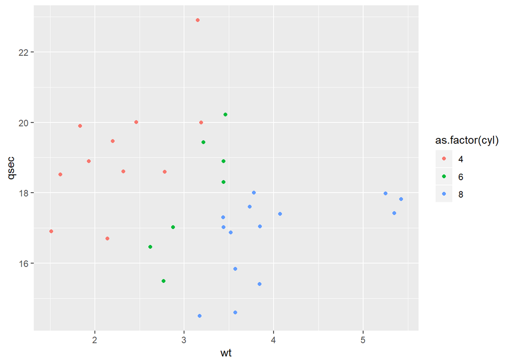

```r
ggplot(mtcars,aes(x=wt,
                  y=qsec,
                  col=as.factor(cyl)))+
  geom_point()
```

Note that you can combine several geometries:

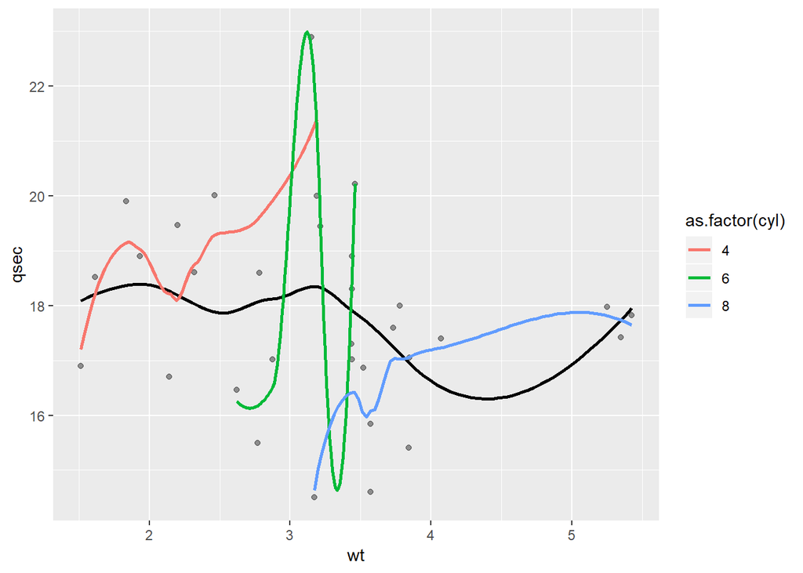

```r
ggplot(mtcars,aes(x=wt,
                  y=qsec))+
  geom_point(alpha=0.4)+
  geom_smooth(se=FALSE,col="black")+
  geom_smooth(aes(col=as.factor(cyl)),se=FALSE)
```

Look like to over fit too much + I would like to have indicators for each points

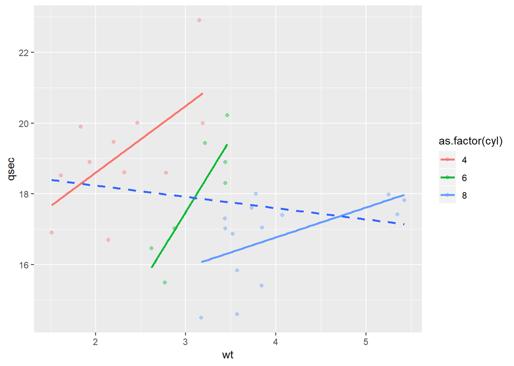

```r
ggplot(mtcars,aes(x=wt,
                  y=qsec,
                  col=as.factor(cyl)))+
  geom_point(alpha=0.4)+
  geom_smooth(method = "lm", se = FALSE) +
  geom_smooth(aes(group = 1), method = "lm", se = FALSE, linetype = 2)
```

You can change the display of your geomtry in the geom_layer

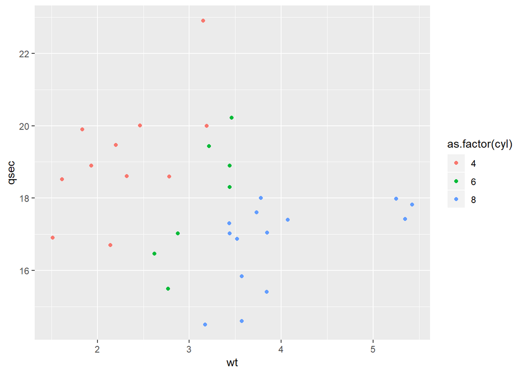

```r
ggplot(mtcars, aes(x=wt,y=qsec, col=as.factor(cyl)))+geom_point()
```

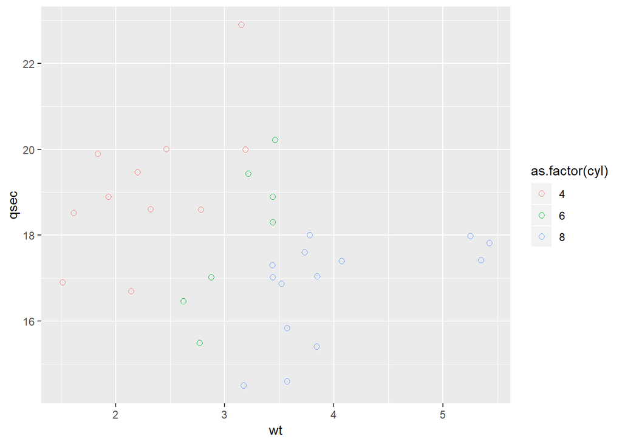

```r
ggplot(mtcars, aes(x=wt,y=qsec, col=as.factor(cyl)))+geom_point(shape=1, size=2)
```

The mapping did not change !

| Aesthetic | Description |
| --- | --- |
| x | x-axis position |
| y | y-axis position |
| colour | colour of outlines shape |
| fill | fill colour |
| size | Diameter of points, thickness of line |
| alpha | alpha from 0 (invisble) to 1 (opaque) |
| labels | Text on a plot or axes |
| linetype | Line dash pa!ern |
| shape | Shape |